# Logic and Scientific Thinking

Final Review

Bogdan G. Popescu

bgpopescu@tec.mx

Tecnologico de Monterrey

## Five Skills

By the end of the course, you can:

1. **Reconstruct** arguments — including the premises a speaker never states.
2. **Name** the fallacy — and say what would decide the question.
3. **Take apart** persuasion — the appeals, and where misinformation fails.
4. **Evaluate** evidence: correlation, samples, polls, sources.
5. **Apply** it all to a real specimen — cold, in the speaker’s own words.

## Five Weeks

- **16 sessions · 11 readings · two exams · five weeks.**
- Readings from **Plato to 2019**. None of it filler.
- A logic course usually takes a semester.
- Half of you said the pace was **too fast**. Fair.
- That was the design, not an accident.
- Hence the repetition, the drills, and today.

## One Reading, One Tool

Every reading was the source of one session’s instrument:

- **Sagan** — the checklist you run before believing a claim. *(S1)*
- **Plato** — why listing examples never says what a thing is. *(S2)*
- **Hume, twice** — is/ought, then why induction never proves. *(S3–4)*
- **Vaughn** — the words for grading: valid, sound, strong. *(S5, S7)*
- **Kahneman** — why a good story beats a good argument. *(S6)*
- The same holds for Sessions 10–13. Work out which.

## What You Can Do Now

- Read a study and say **what would settle it**.
- **Name the move** in words the speaker would recognise.
- Tell a **bad argument** from a **false conclusion**.
- Not logic class: the next contract, diagnosis, viral claim.

## Exam Format

- Closed book, individual, in class.
- Covers **Sessions 10–13**.
- Tests the concepts, the vocabulary, and their application to short cases.
- The **required readings** for those sessions are examinable.

**Session 14 is a workshop and is not examined.** Neither is anything from the midterm.

## Grading

| Component | Weight |
| --- | --- |
| Midterm exam | **30%** |
| Final exam | **30%** |
| Reading | 20% |
| Attendance | 10% |
| Participation | 10% |

Two exams, **60%** together — and neither one is cumulative.

**Reading 20%** — tested on the exams. **Attendance and participation 20%** — earned in the room.

# Teaching Evaluation

[figure not shown]

forms.gle/3VzPTovn8FxbWSUG9

# Part 1: The Whole Toolkit

## Where the Catalogue Stands

| Family | Fallacies | Where |
| --- | --- | --- |
| **Faulty reasoning** | false cause · circular reasoning | S7 |
| **Misused sources** | ad hominem · appeal to authority | S7 |
| **Distorted claims** | straw man · red herring · slippery slope · equivocation · false dilemma | **S10** |
| **Emotional appeals** | appeal to fear · appeal to pity · bandwagon | **S10** |

**Eight are examinable.** The first four were the midterm and do not come back.

## Distorted Claims

- **Straw man** — answers a weaker version nobody argued for.
- **Red herring** — changes the subject to something easier.
- **Slippery slope** — asserts a chain to disaster without defending any link.
- **Equivocation** — one word, two senses, sliding between them.
- **False dilemma** — offers two options when more exist.

## Emotional Appeals

- **Appeal to fear** — accept this or something terrible happens.
- **Appeal to pity** — accept this because someone is suffering.
- **Bandwagon** — accept this because everyone else has.

An emotion in an argument is **not** automatically a fallacy. The question is whether the feeling is doing work that a reason should be doing.

## The Two Guards

- **The fallacy fallacy** — naming the move does not refute the conclusion.
- **The verbal dispute** — not every disagreement is substantive.

A bad argument for a claim leaves the claim exactly where it was. It still might be true.

## Three Ways an Argument Fails

| Where it breaks | What to say |
| --- | --- |
| **False premise** | that claim is not true |
| **Misleading scope** | every word is true, and the comparison is missing |
| **Hidden link** | the step carrying the conclusion is never stated |

Middle row is the hard one. “Complaints rose 300%” is arithmetic — until you ask **300% of what?**

## The Gish Gallop

Four checks — ask all four before you use the name:

1. **Who** — name the speaker and the setting.
2. **Speed** — faster than any rebuttal could keep up with.
3. **Strategy** — the quantity IS the point.
4. **Weakness** — several claims would not survive checking.

The defence is not to answer everything. **Pick one claim, demand its evidence, and say why you picked it.**

## Ethos, Pathos, Logos

| Appeal | The speaker offers | Grounded when |
| --- | --- | --- |
| **Ethos** | who I am | you can check the credential and the grounds |
| **Pathos** | what you feel | the feeling is real *and* comes with something you can check |
| **Logos** | the reasoning | the steps are given and checkable |

**One test for all three rows:** a **grounded** appeal hands you something you could go and check — a record, a number, a plan. An **ungrounded** one hands you a feeling, or a name, and asks you to stop there.

## What Grounded Looks Like

Session 12’s own pairs — same appeal, opposite verdict:

|  | Grounded | Ungrounded |
| --- | --- | --- |
| **Ethos** | the cardiologist who shows **how** she knows | the rented *white coat* in the advert |
| **Pathos** | a real danger — **plus what to do** | fear doing *all* the work |
| **Logos** | “here is the calculation — check it” | “*studies show*…” |

Read down the **Ungrounded** column: a name, a feeling, a gesture at evidence. Not one of them hands you anything you could go and look at.

## Four Explanations of a Correlation

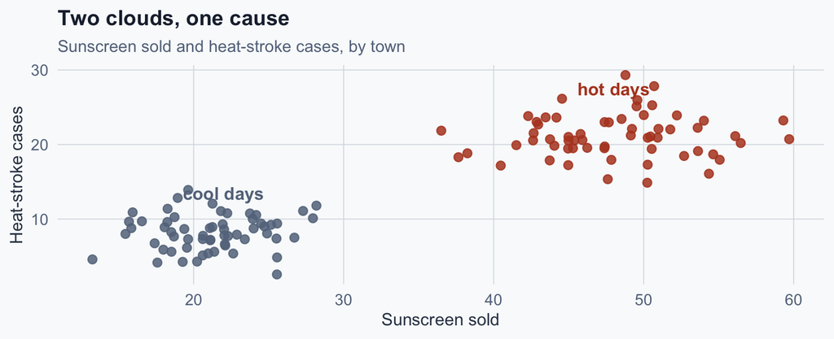

Ignore the colour and the two clouds become one upward line. **The correlation is real. The cause is the weather.**

## The Four, In Order of Habit

1. **X causes Y** — the reading everyone reaches for first.
2. **Reverse causation** — Y causes X. Ask which came first.
3. **Confounder** — a third thing causes both. **Name it.**
4. **Chance** — small numbers, or enough tries that a streak was coming.

Only **random assignment or control** licenses number 1, because it is the only thing that removes 2, 3 and 4 at once.

## Reading a Study

Four questions, in this order:

- **Who was studied?** — who is in the sample, who chose them, and who is missing?
- **What was actually measured?** — is the number the thing, or a proxy for it?
- **Compared to what?** — what tells us the programme made the difference?
- **How was the result selected?** — the planned test, or the one that looked best?

**Who? What? Compared to what? How was it selected?**

Funding is a reason to **look harder at the method**. It is not, by itself, a refutation.

## The Readings

- Schopenhauer, A. (c. 1831/1896). *The art of controversy* (T. B. Saunders, Trans.). Swan Sonnenschein. **Required — S10.**
- Institute for Propaganda Analysis. (1937). How to detect propaganda. *Propaganda Analysis, 1*(2), 5–8. **Required — S11.**
- Aristotle. (n.d.). *Rhetoric*, Book I, Chs. 1–2. **Required — S12.**
- Huff, D. (1954). The sample with the built-in bias. In *How to lie with statistics* (Ch. 1). W. W. Norton. **Required — S13.**

# Part 2: Practice

*Six drills. Answers on the slide immediately after each.*

## Drill 1 — Name the Move

**1. P1:** I am proposing a bike lane on Constitución.  
**P2:** So you want a city where nobody is allowed to own a car.

**2. P1:** She raised the safety inspection at the meeting.  
**P2:** I would rather talk about who leaked it to the press.

**3. P1:** Can I park here?  
**P2:** The sign says *fine for parking here*, so it is fine to park here.

**4. P1:** Should we let one student submit late?  
**P2:** If we let one submit late, by December nobody will hand anything in on time.

**5. P1:** He broke the rule, so he should be disqualified.  
**P2:** He trained eight years for this.

## Drill 1 — Answers

|  | P2’s move | Why |
| --- | --- | --- |
| **1** | **straw man** | answers “ban all cars”, which nobody proposed |
| **2** | **red herring** | the inspection is abandoned, not misrepresented |
| **3** | **equivocation** | *fine* = a penalty, then *fine* = acceptable |
| **4** | **slippery slope** | a chain to disaster, no link defended |
| **5** | **appeal to pity** | the training is real and irrelevant to the rule |

**1 vs. 2 is the pair worth remembering:** straw man deforms the claim, red herring drops it.

## Part A — On the Exam

**A1.** “Either we raise the fare or the metro stops running.”  
**A2.** “Four of the six departments have already adopted it, so we should too.”

Write only this:

> A1 – false dilemma A2 – bandwagon

A name each. **No sentences, no reasons** — and **each of the eight is used exactly once**, so a name you have already spent is a name you cannot spend again.

## Drill 2 — Fair Move, or Not?

**1. P1:** Her argument for the cut is a straw man of what the department said.  
**P2:** So she is wrong about the budget.

**2. P1:** The project failed.  
**P2:** Failed by what — cost, schedule, or whether anyone uses it?

**3. P1:** This poll shows we are ahead.  
**P2:** It was run by the party it favours. How were the respondents selected?

**4. P1:** This poll shows we are ahead.  
**P2:** It was run by the party it favours, so the numbers are fiction.

## Drill 2 — Answers

|  | P2’s move | Why |
| --- | --- | --- |
| **1** | **not a fair move** | the fallacy fallacy — the budget claim may still be true |
| **2** | **fair move** | fixes the word before arguing about it |
| **3** | **fair move** | the interest raises a question, and the question is asked |
| **4** | **not a fair move** | the interest is treated as the finding |

**3 and 4 differ by one clause.** That clause is the whole lesson.

## Drill 3 — Which Appeal, and Is It Grounded?

**1.** “I have taught this course for twenty years.”

**2.** “I inspected this bridge myself in January. Here is the report and the photographs.”

**3.** “Think of the families who cannot sleep for the noise. The night-flight ban starts in April — here is the schedule.”

**4.** “If this passes, you will not recognise your own neighbourhood.”

**5.** “Nine studies agree.”

**6.** “Twelve of the fifteen buses on this route ran late last month. Here is the timetable and the operator’s log.”

## Drill 3 — Answers

|  | Appeal | Verdict | Why |
| --- | --- | --- | --- |
| **1** | ethos | **ungrounded** | seniority offered instead of grounds |
| **2** | ethos | **grounded** | hands you the means of checking her |
| **3** | pathos | **grounded** | real feeling, attached to a specific plan |
| **4** | pathos | **ungrounded** | the fear does all the work |
| **5** | logos | **ungrounded** | *which* nine, on whom, measuring what? |
| **6** | logos | **grounded** | the count is given, and so is where to go and check it |

**Grounded does not mean right.** A careful liar can hand you a checkable number too.

## Part C — On the Exam

**C1.** “Trust me, I have been doing this since before you were born.”

Write **three** things:

> **ethos · ungrounded** — age is offered in place of any reason to think the claim is true.

Two labels, one sentence. **Two points for the pair, two for the reason.**

**Wording:** the paper says *grounded / ungrounded*. The Session 12 slides said *honest / counterfeit*. **Both are accepted.**

## Drill 4 — Explain the Correlation

**1.** “Countries with more Nobel laureates eat more chocolate. So chocolate makes you brilliant.”

**2.** “People who see a physiotherapist have more back pain than people who do not. So physiotherapy causes back pain.”

**3.** “A sports magazine compared thirty pre-match habits with whether teams won. Eating pasta came out on top. So pasta wins matches.”

**4.** “Plots randomly assigned the new fertiliser yielded more than the control plots. So the fertiliser works.”

## Drill 4 — Answers

|  | Explanation | The rival, named |
| --- | --- | --- |
| **1** | **confounder** | national wealth — rich countries buy chocolate *and* fund laboratories |
| **2** | **reverse causation** | the back pain is why they went |
| **3** | **chance** | thirty habits were compared, so one had to come out on top |
| **4** | **X causes Y** | random assignment removed the other three |

**“Correlation is not causation” earns nothing.** Naming the rival earns the mark.

## Part E — On the Exam

**E1.** “Towns with more streetlights report more night-time crime. So streetlights attract crime.”

Write **both**:

> **confounder — town size.** Bigger towns have more lights *and* more crime of every kind.

**Naming the confounder is worth as much as the label.** “Confounder” alone scores one of two — and there are **ten** of these on the paper, so it adds up fast.

## Drill 5 — Read the Study

> The city reports that its **after-school programme raised attendance by 9%**. Schools **chose** whether to join. Attendance was recorded by the **programme’s own coordinators**. The 9% compares joining schools **with their own attendance the year before**. The figure reported is the one **for primary schools**, where the effect was largest.

**(a)** How did these schools end up in the study? **(b)** What was actually measured? **(c)** Compared to what? **(d)** Why is the reported figure 9% and not some other number?

## Drill 5 — Answers

- **(a) How they ended up in the study.** Schools *chose*. The joiners differ from the non-joiners before the programme does anything — an organised school is likelier both to join and to have good attendance already.
- **(b) What was measured.** Attendance was recorded by the people delivering the programme, and nobody independent checked it.
- **(c) Compared to what.** Against their own previous year — so any city-wide trend, or any rebound from a bad year, is counted as programme effect. The comparison needed is **similar schools that did not join**, over the same months.
- **(d) Why 9% and not another number.** Primary schools are the subgroup where the effect was *largest* — several were looked at and the best was published. So you **cannot** say the programme raises attendance by 9%, nor that it works especially well for primary schools.

## Part F — On the Exam

One study. Four questions. **14 points, and the four are not worth the same.**

- 1. and (b) want a **named problem plus why it matters** — two marks for the problem, one for the why. Three points each.
- 3. is worth four: two for naming the comparison actually made — each student against their own past — and two for the **real comparison** that is needed instead.
- 4. wants **both halves**: the subgroup was picked *after* the results were seen, *and* what that does **not** let you conclude: not that the app raises marks by 11%, and not that it works especially well for engineers.

Budget your time backwards from here. Parts A and G take five minutes between them.

## Drill 6 — Match the Reading

**1.** Schopenhauer, *The Art of Controversy*  
**2.** Institute for Propaganda Analysis (1937)  
**3.** Aristotle, *Rhetoric* I.1–2  
**4.** Huff, “The Sample with the Built-in Bias”

(a) how a poll is steered by who gets asked, long before the questions are written  
(b) the moves of someone who wants to win when being right is not the goal  
(c) what a speaker has to work with: who they are, what you feel, what follows  
(d) the named tricks a campaign uses to carry a crowd along  
(e) the four rival explanations to rule out before believing a correlation

## Drill 6 — Answers

|  | Reading |  |
| --- | --- | --- |
| **1** | Schopenhauer | **(b)** the moves of someone who wants to win |
| **2** | Propaganda Analysis (1937) | **(d)** the named tricks that carry a crowd |
| **3** | Aristotle | **(c)** who they are, what you feel, what follows |
| **4** | Huff | **(a)** who gets asked, before the questions are written |

**Left over: (e)** — the four rivals for a correlation. That is Session 13 **class** material, not a reading. **The leftover is never a reading**, so there is no title to recognise.

## Part G — On the Exam

Match each **required** reading to what it is mainly about. One option is left over.

The leftover is **not a reading at all** — it is a topic from class. There is no title to recognise, so the only way through is knowing what each of the four is about.

Four required: **Schopenhauer · the 1937 propaganda article · Aristotle · Huff.** One line each is the whole revision.

## Conclusion

- **Practise, don’t re-read.** Redo the drills with the answers covered.
- **Name the eight** out loud, by family. *distorted claims · emotional appeals*
- **Say what would settle it** — for a fallacy, for a correlation, for a study.
- **Name the rival.** Never “correlation is not causation” on its own.
- **One line per reading** — what it was about, nothing more.

The question the whole paper asks, in every part: **and what would decide it?**